# Mixed ANOVA + Pairwise Comparison

5/7/2021

# Description

**Source of motivation: [Mixed ANOVA in R](https://www.datanovia.com/en/lessons/mixed-anova-in-r)** **Adapted from Ruslan Klymentiev RAnovas_main.R for the same project**

## Assumptions Check

**Outliers**. Values above `Q3 + 1.5xIQR` or below `Q1 - 1.5xIQR` are considered as outliers. Values above `Q3 + 3xIQR` or below `Q1 - 3xIQR` are considered as extreme points (or extreme outliers). Observations that are considered as extreme points are marked red.

**Normality Assumptions**. Plot shows Q-Q plot for subsets of data. If points lie on the line, we can assume that data is fairly symmetrical (and that’s what we want).

**Homogeneity of Variance Assumption**. Performed using [Levene’s test](https://en.wikipedia.org/wiki/Levene%27s_test).

$H_0$: the groups have equal population variances $H_A$: the groups don’t have equal population variances Observations with p-value < 0.05 are marked red, since they may violate the ANOVA results.

## Mixed ANOVA

“*In statistics, a mixed-design analysis of variance model, also known as a split-plot ANOVA, is used to test for differences between two or more independent groups whilst subjecting participants to repeated measures.*” ([Wikipedia](https://en.wikipedia.org/wiki/Mixed-design_analysis_of_variance))

within subjects group (with repeated measures): `Measurement` between subjects group: `Group`

## Post-hoc Tests

**Significant two-way interaction**. Can be used if an interaction term in Mixed ANOVA results showed significance. In other words, impact of `Group` on the outcome variable (`VectorStrength`) depends on the `Measurement` (and vice versa)

**Effect of `Group` at each `Measurement`**. Shows the **simple main effect** of the `Group`

**Pairwise comparisons between `Group`**. Performs [Welch’s t-tests](https://en.wikipedia.org/wiki/Welch%27s_t-test) (for unequal variances) for comparing `Group` for each `Measurement`

**Effect of `Measurement` at each level of `Group`**. Shows the **simple main effect** of the **`Measurement`**

**Pairwise comparisons between `Measurement`**. Performs **paired** two-sample t-test for comparing `Measurement` for each `Group`.

**Non-significant two-way interaction**. Shows the **main effect** for `Group` and `Measurement`. Used if there was non-significant two-way interaction.

For each table observations with adjusted p-value (using Bonferroni correction) which is less then 0.05 are marked green.

```r
library(tidyverse)
library(ggpubr)
library(rstatix)
library(knitr)
library(kableExtra)
```

```r
raw_data <- read_csv("D:/DynamicCSDjl/Data/VSoutput/AM_5_VectorStrength_Stats.csv")
data_type <- "AM"

layers <- unique(raw_data$Layer)
stimfreq <- 5
metrics <- c("VectorStrenght")

red_color <- "#ffb3b3"
green_color <- "#d6f5d6"

# values for testing
freq <- 5
layer <- "All"
metric <- "VectorStrenght"
```

# Results

```r
for (layer in layers){
  # for (layer in c("All", "I_II")){
  cat("###", layer, " Layer {.tabset .tabset-fade .tabset-pills}\n")

  model_data <- raw_data %>%
    filter(
      Layer == layer)

  model_data <- model_data %>%
    select(Group, Animal, Measurement, VectorStrenght)

  if(grepl("CL", data_type)) {
    model_data <- model_data %>%
      convert_as_factor(Group, Animal, Measurement) %>%
      reorder_levels(
        Measurement,
        order = c("preCL_1", "CL_1", "CL_2", "CL_3", "CL_4"))
  } else {
    model_data <- model_data %>%
      filter(Measurement != "AM_5") %>%
      reorder_levels(
        Measurement,
        order = c("preAM_1", "AM_1", "AM_2", "AM_3", "AM_4"))
  }

  cat("####", metric, "{.tabset .tabset-fade .tabset-pills}\n")

  cat("##### Assumptions Check\n")

  cat("<b>===OUTLIERS===</b>\n\n")

  df <- model_data %>%
    group_by(Measurement, Group) %>%
    identify_outliers(eval(metric))

  if(nrow(df) > 0){
    df %>%
      kable(escape = F, digits = 6) %>%
      kable_classic_2(full_width = F) %>%
      kable_styling() %>%
      row_spec(
        which(df$is.extreme == TRUE), bold = T,
        background = red_color) %>%
      print()
  } else{
    cat("\n\nNo outliers were detected.\n\n")
  }

  cat("\n\n<b>===NORMALITY ASSUMPTION===</b>\n\n")

  p <- ggqqplot(model_data, metric, ggtheme = theme_bw()) +
    facet_grid(Measurement ~ Group)
  plot(p)

  cat("\n\n<b>===HOMOGENEITY OF VARIANCE ASSUMPTION===</b>\n\n")

  df <- model_data %>%
    group_by(Measurement) %>%
    levene_test(formula = as.formula(paste0(metric, "~ Group")))

  df %>%
    kable(escape = F, digits = 3) %>%
    kable_classic_2(full_width = F) %>%
    kable_styling() %>%
    row_spec(
      which(df$p <= 0.05), bold = T,
      background = red_color) %>%
    print()

  cat('\n\n')

  cat("##### Mixed ANOVA\n")

  # Two-way mixed ANOVA test
  res.aov <- anova_test(
    data = model_data, dv = eval(metric), wid = Animal,
    between = Group, within = Measurement)

  df <- get_anova_table(res.aov) %>%
    data.frame()

  df %>%
    kable(escape = F) %>%
    kable_classic_2(full_width = F) %>%
    kable_styling() %>%
    row_spec(
      which(df$p <= 0.05), bold = T,
      background = green_color) %>%
    print()

  cat('\n\n')

  cat("##### Post-hoc Tests\n")

  cat("\n\n<b>===SIGNIFICANT TWO-WAY INTERACTION===</b>\n\n")

  cat("\n\n\n<b>=EFFECT OF GROUP AT EACH MEASUREMENT=</b>\n\n")

  one.way <- model_data %>%
    group_by(Measurement) %>%
    anova_test(dv = eval(metric), wid = Animal, between = Group) %>%
    get_anova_table() %>%
    adjust_pvalue(method = "bonferroni")

  df <- one.way %>%
    data.frame() %>%
    select(-F)
  df %>%
    kable(escape = F) %>%
    kable_classic_2(full_width = F) %>%
    kable_styling() %>%
    row_spec(
      which(df$p.adj <= 0.05), bold = T,
      background = green_color) %>%
    print()

  cat("\n\n\n<b>=PAIRWISE COMPARISONS BETWEEN GROUP LEVELS=</b>\n\n")

  pwc <- model_data %>%
    group_by(Measurement) %>%
    pairwise_t_test(
      as.formula(paste0(metric, "~ Group")),
      p.adjust.method = "bonferroni",
      pool.sd = FALSE,
      var.equal = FALSE)

  eff_size <- model_data %>%
    group_by(Measurement) %>%
    cohens_d(
      as.formula(paste0(metric, "~ Group")),
      var.equal = FALSE)

  df <- pwc %>%
    left_join(eff_size) %>%
    data.frame()

  df %>%
    kable(escape = F, digits = 3) %>%
    kable_classic_2(full_width = F) %>%
    kable_styling() %>%
    row_spec(
      which(df$p.adj <= 0.05), bold = T,
      background = green_color) %>%
    print()

  cat("\n\n\n<b>=EFFECT OF MEASUREMENT AT EACH LEVEL OF GROUP=</b>\n\n")

  one.way2 <- model_data %>%
    group_by(Group) %>%
    anova_test(dv = eval(metric), wid = Animal, within = Measurement) %>%
    get_anova_table() %>%
    adjust_pvalue(method = "bonferroni")

  df <- one.way2 %>%
    data.frame()
  df %>%
    kable(escape = F) %>%
    kable_classic_2(full_width = F) %>%
    kable_styling() %>%
    row_spec(
      which(df$p.adj <= 0.05), bold = T,
      background = green_color) %>%
    print()

  cat("\n\n\n<b>=PAIRWISE COMPARISONS BETWEEN MEASUREMENTS AT EACH GROUP LEVELS=</b>\n\n")

  exclude_animals <- model_data %>%
    group_by(Animal) %>%
    summarise(n = n_distinct(Measurement)) %>%
    filter(n < 5) %>%
    pull(Animal)

  pwc2 <- model_data %>%
    filter(!(Animal %in% exclude_animals)) %>%
    group_by(Group) %>%
    pairwise_t_test(
      as.formula(paste0(metric, "~ Measurement")),
      paired = TRUE,
      pool.sd = FALSE,
      var.equal = FALSE,
      p.adjust.method = "bonferroni"
    )

  eff_size2 <- model_data %>%
    filter(!(Animal %in% exclude_animals)) %>%
    group_by(Group) %>%
    cohens_d(
      as.formula(paste0(metric, "~ Measurement")),
      paired = TRUE,
      var.equal = FALSE)

  df <- pwc2 %>%
    left_join(eff_size2) %>%
    data.frame()
  df %>%
    kable(escape = F, digits = 3) %>%
    kable_classic_2(full_width = F) %>%
    kable_styling() %>%
    row_spec(
      which(df$p.adj <= 0.05), bold = T,
      background = green_color) %>%
    print()

  cat("\n\n\n<b>===NON-SIGNIFICANT TWO-WAY INTERACTION===</b>\n\n")
  cat("\n\n\n<b>=MAIN EFFECT OF MEASUREMENT=</b>\n\n")

  df <- model_data %>%
    filter(!(Animal %in% exclude_animals)) %>%
    pairwise_t_test(
      as.formula(paste0(metric, "~ Measurement")),
      paired = TRUE,
      p.adjust.method = "bonferroni"
    ) %>%
    data.frame()

  df %>%
    kable(escape = F) %>%
    kable_classic_2(full_width = F) %>%
    kable_styling() %>%
    row_spec(
      which(df$p.adj <= 0.05), bold = T,
      background = green_color) %>%
    print()

  cat("\n\n\n<b>=MAIN EFFECT OF GROUP=</b>\n\n")

  df <- model_data %>%
    pairwise_t_test(
      as.formula(paste0(metric, "~ Group")),
      p.adjust.method = "bonferroni"
    ) %>%
    data.frame()

  df %>%
    kable(escape = F) %>%
    kable_classic_2(full_width = F) %>%
    kable_styling() %>%
    row_spec(
      which(df$p.adj <= 0.05), bold = T,
      background = green_color) %>%
    print()

  cat('\n\n')

  cat("##### Plots\n")

  pwc <- pwc %>% add_xy_position(x = "Measurement")
  pwc2 <- pwc2 %>% add_xy_position(x = "Group")

  box_plot <- ggboxplot(
    model_data, x = "Measurement", y = metric,
    color = "Group", palette = "jco"
  )

  box_plot2 <- ggboxplot(
    model_data, x = "Group", y = metric,
    color = "Measurement", palette = "jco"
  )

  p <- box_plot +
    stat_pvalue_manual(pwc, tip.length = 0.01, hide.ns = TRUE) +
    labs(
      title = paste0(metric, " for ", layer, " Layer, ", freq, "Hz and 1st Click"),
      subtitle = get_test_label(res.aov, detailed = TRUE),
      caption = get_pwc_label(pwc)
    )

  plot(p)

  cat('\n\n')

  p <- box_plot2 +
    stat_pvalue_manual(pwc2, tip.length = 0.01, hide.ns = TRUE) +
    labs(
      title = paste0(metric, " for ", layer, " Layer, ", freq, "Hz and 1st Click"),
      subtitle = get_test_label(res.aov, detailed = TRUE),
      caption = get_pwc_label(pwc2)
    )

  plot(p)

  cat('\n\n')
}
```

### All Layer

#### VectorStrenght

##### Assumptions Check

**===OUTLIERS===**

| Group | Measurement | Animal | VectorStrenght | is.outlier | is.extreme |
| --- | --- | --- | --- | --- | --- |
| KIV | preAM_1 | KIV12 | 0.874825 | TRUE | FALSE |
| KIV | AM_1 | KIV12 | 0.815179 | TRUE | FALSE |
| KIC | AM_2 | KIC04 | 0.802247 | TRUE | FALSE |
| KIT | AM_4 | KIT07 | 0.681549 | TRUE | FALSE |
| KIT | AM_4 | KIT09 | 0.897394 | TRUE | FALSE |

**===NORMALITY ASSUMPTION===**

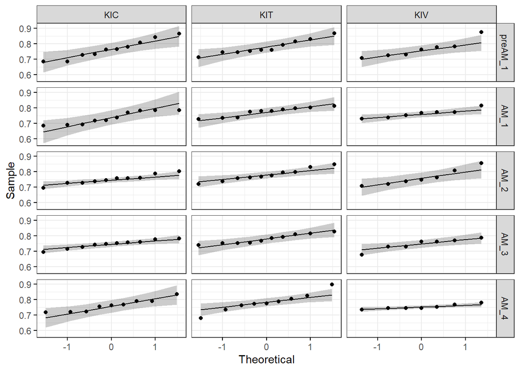

**===HOMOGENEITY OF VARIANCE ASSUMPTION===**

| Measurement | df1 | df2 | statistic | p |
| --- | --- | --- | --- | --- |
| preAM_1 | 2 | 24 | 0.264 | 0.770 |
| AM_1 | 2 | 24 | 1.757 | 0.194 |
| AM_2 | 2 | 24 | 0.588 | 0.563 |
| AM_3 | 2 | 24 | 0.264 | 0.770 |
| AM_4 | 2 | 22 | 1.956 | 0.165 |

##### Mixed ANOVA

| Effect | DFn | DFd | F | p | p..05 | ges |
| --- | --- | --- | --- | --- | --- | --- |
| Group | 2 | 22 | 2.751 | 0.086 |  | 0.098 |
| Measurement | 4 | 88 | 0.669 | 0.615 |  | 0.017 |
| Group:Measurement | 8 | 88 | 0.417 | 0.908 |  | 0.021 |

##### Post-hoc Tests

**===SIGNIFICANT TWO-WAY INTERACTION===**

**=EFFECT OF GROUP AT EACH MEASUREMENT=**

Measurement

Effect

DFn

DFd

p

p..05

ges

p.adj

preAM_1

Group

2

24

0.845

0.014

1.000

AM_1

Group

2

24

0.062

0.207

0.310

AM_2

Group

2

24

0.274

0.102

1.000

AM_3

Group

2

24

0.033

0.247

0.165

AM_4

Group

2

22

0.399

0.080

1.000

**=PAIRWISE COMPARISONS BETWEEN GROUP LEVELS=**

Measurement

.y.

group1

group2

n1

n2

statistic

df

p

p.adj

p.adj.signif

effsize

magnitude

preAM_1

VectorStrenght

KIC

KIT

10

10

-0.526

16.976

0.605

1.000

ns

-0.235

small

preAM_1

VectorStrenght

KIC

KIV

10

7

-0.012

13.824

0.991

1.000

ns

-0.006

negligible

preAM_1

VectorStrenght

KIT

KIV

10

7

0.485

11.660

0.637

1.000

ns

0.242

small

AM_1

VectorStrenght

KIC

KIT

10

10

-2.309

16.440

0.034

0.103

ns

-1.033

large

AM_1

VectorStrenght

KIC

KIV

10

7

-1.635

15.000

0.123

0.369

ns

-0.780

moderate

AM_1

VectorStrenght

KIT

KIV

10

7

0.675

13.553

0.511

1.000

ns

0.331

small

AM_2

VectorStrenght

KIC

KIT

10

10

-1.873

16.979

0.078

0.235

ns

-0.838

large

AM_2

VectorStrenght

KIC

KIV

10

7

-0.564

8.934

0.586

1.000

ns

-0.290

small

AM_2

VectorStrenght

KIT

KIV

10

7

0.741

10.656

0.475

1.000

ns

0.373

small

AM_3

VectorStrenght

KIC

KIT

10

10

-2.680

17.781

0.015

0.046

-1.198

large

AM_3

VectorStrenght

KIC

KIV

10

7

0.000

10.520

1.000

1.000

ns

0.000

negligible

AM_3

VectorStrenght

KIT

KIV

10

7

2.058

11.453

0.063

0.189

ns

1.030

large

AM_4

VectorStrenght

KIC

KIT

9

9

-0.845

13.786

0.412

1.000

ns

-0.398

small

AM_4

VectorStrenght

KIC

KIV

9

7

0.640

11.074

0.535

1.000

ns

0.308

small

AM_4

VectorStrenght

KIT

KIV

9

7

1.409

9.407

0.191

0.573

ns

0.670

moderate

**=EFFECT OF MEASUREMENT AT EACH LEVEL OF GROUP=**

| Group | Effect | DFn | DFd | F | p | p..05 | ges | p.adj |
| --- | --- | --- | --- | --- | --- | --- | --- | --- |
| KIC | Measurement | 4 | 32 | 0.774 | 0.550 |  | 0.066 | 1 |
| KIT | Measurement | 4 | 32 | 0.042 | 0.996 |  | 0.003 | 1 |
| KIV | Measurement | 4 | 24 | 0.818 | 0.526 |  | 0.042 | 1 |

**=PAIRWISE COMPARISONS BETWEEN MEASUREMENTS AT EACH GROUP LEVELS=**

| Group | .y. | group1 | group2 | n1 | n2 | statistic | df | p | p.adj | p.adj.signif | effsize | magnitude |
| --- | --- | --- | --- | --- | --- | --- | --- | --- | --- | --- | --- | --- |
| KIC | VectorStrenght | preAM_1 | AM_1 | 9 | 9 | 1.045 | 8 | 0.326 | 1 | ns | 0.348 | small |
| KIC | VectorStrenght | preAM_1 | AM_2 | 9 | 9 | 0.598 | 8 | 0.566 | 1 | ns | 0.199 | negligible |
| KIC | VectorStrenght | preAM_1 | AM_3 | 9 | 9 | 0.862 | 8 | 0.414 | 1 | ns | 0.287 | small |
| KIC | VectorStrenght | preAM_1 | AM_4 | 9 | 9 | 0.151 | 8 | 0.884 | 1 | ns | 0.050 | negligible |
| KIC | VectorStrenght | AM_1 | AM_2 | 9 | 9 | -0.787 | 8 | 0.454 | 1 | ns | -0.262 | small |
| KIC | VectorStrenght | AM_1 | AM_3 | 9 | 9 | -0.491 | 8 | 0.637 | 1 | ns | -0.164 | negligible |
| KIC | VectorStrenght | AM_1 | AM_4 | 9 | 9 | -1.290 | 8 | 0.233 | 1 | ns | -0.430 | small |
| KIC | VectorStrenght | AM_2 | AM_3 | 9 | 9 | 0.591 | 8 | 0.571 | 1 | ns | 0.197 | negligible |
| KIC | VectorStrenght | AM_2 | AM_4 | 9 | 9 | -1.001 | 8 | 0.346 | 1 | ns | -0.334 | small |
| KIC | VectorStrenght | AM_3 | AM_4 | 9 | 9 | -1.746 | 8 | 0.119 | 1 | ns | -0.582 | moderate |
| KIT | VectorStrenght | preAM_1 | AM_1 | 9 | 9 | 0.206 | 8 | 0.842 | 1 | ns | 0.069 | negligible |
| KIT | VectorStrenght | preAM_1 | AM_2 | 9 | 9 | -0.204 | 8 | 0.843 | 1 | ns | -0.068 | negligible |
| KIT | VectorStrenght | preAM_1 | AM_3 | 9 | 9 | 0.062 | 8 | 0.952 | 1 | ns | 0.021 | negligible |
| KIT | VectorStrenght | preAM_1 | AM_4 | 9 | 9 | -0.055 | 8 | 0.957 | 1 | ns | -0.018 | negligible |
| KIT | VectorStrenght | AM_1 | AM_2 | 9 | 9 | -0.463 | 8 | 0.656 | 1 | ns | -0.154 | negligible |
| KIT | VectorStrenght | AM_1 | AM_3 | 9 | 9 | -0.249 | 8 | 0.810 | 1 | ns | -0.083 | negligible |
| KIT | VectorStrenght | AM_1 | AM_4 | 9 | 9 | -0.270 | 8 | 0.794 | 1 | ns | -0.090 | negligible |
| KIT | VectorStrenght | AM_2 | AM_3 | 9 | 9 | 0.312 | 8 | 0.763 | 1 | ns | 0.104 | negligible |
| KIT | VectorStrenght | AM_2 | AM_4 | 9 | 9 | 0.094 | 8 | 0.927 | 1 | ns | 0.031 | negligible |
| KIT | VectorStrenght | AM_3 | AM_4 | 9 | 9 | -0.102 | 8 | 0.921 | 1 | ns | -0.034 | negligible |
| KIV | VectorStrenght | preAM_1 | AM_1 | 7 | 7 | 0.282 | 6 | 0.787 | 1 | ns | 0.107 | negligible |
| KIV | VectorStrenght | preAM_1 | AM_2 | 7 | 7 | 0.317 | 6 | 0.762 | 1 | ns | 0.120 | negligible |
| KIV | VectorStrenght | preAM_1 | AM_3 | 7 | 7 | 1.391 | 6 | 0.214 | 1 | ns | 0.526 | moderate |
| KIV | VectorStrenght | preAM_1 | AM_4 | 7 | 7 | 0.675 | 6 | 0.525 | 1 | ns | 0.255 | small |
| KIV | VectorStrenght | AM_1 | AM_2 | 7 | 7 | 0.032 | 6 | 0.975 | 1 | ns | 0.012 | negligible |
| KIV | VectorStrenght | AM_1 | AM_3 | 7 | 7 | 1.912 | 6 | 0.104 | 1 | ns | 0.723 | moderate |
| KIV | VectorStrenght | AM_1 | AM_4 | 7 | 7 | 0.993 | 6 | 0.359 | 1 | ns | 0.375 | small |
| KIV | VectorStrenght | AM_2 | AM_3 | 7 | 7 | 0.991 | 6 | 0.360 | 1 | ns | 0.374 | small |
| KIV | VectorStrenght | AM_2 | AM_4 | 7 | 7 | 0.606 | 6 | 0.567 | 1 | ns | 0.229 | small |
| KIV | VectorStrenght | AM_3 | AM_4 | 7 | 7 | -0.661 | 6 | 0.533 | 1 | ns | -0.250 | small |

**===NON-SIGNIFICANT TWO-WAY INTERACTION===**

**=MAIN EFFECT OF MEASUREMENT=**

| .y. | group1 | group2 | n1 | n2 | statistic | df | p | p.adj | p.adj.signif |
| --- | --- | --- | --- | --- | --- | --- | --- | --- | --- |
| VectorStrenght | preAM_1 | AM_1 | 25 | 25 | 1.0512036 | 24 | 0.304 | 1 | ns |
| VectorStrenght | preAM_1 | AM_2 | 25 | 25 | 0.5150000 | 24 | 0.611 | 1 | ns |
| VectorStrenght | preAM_1 | AM_3 | 25 | 25 | 1.2684031 | 24 | 0.217 | 1 | ns |
| VectorStrenght | preAM_1 | AM_4 | 25 | 25 | 0.3566484 | 24 | 0.724 | 1 | ns |
| VectorStrenght | AM_1 | AM_2 | 25 | 25 | -0.8199566 | 24 | 0.420 | 1 | ns |
| VectorStrenght | AM_1 | AM_3 | 25 | 25 | 0.3119800 | 24 | 0.758 | 1 | ns |
| VectorStrenght | AM_1 | AM_4 | 25 | 25 | -0.8107742 | 24 | 0.425 | 1 | ns |
| VectorStrenght | AM_2 | AM_3 | 25 | 25 | 1.1485223 | 24 | 0.262 | 1 | ns |
| VectorStrenght | AM_2 | AM_4 | 25 | 25 | -0.1702070 | 24 | 0.866 | 1 | ns |
| VectorStrenght | AM_3 | AM_4 | 25 | 25 | -1.1044208 | 24 | 0.280 | 1 | ns |

**=MAIN EFFECT OF GROUP=**

.y.

group1

group2

n1

n2

p

p.signif

p.adj

p.adj.signif

VectorStrenght

KIC

KIT

49

49

0.00122

0.00367

VectorStrenght

KIC

KIV

49

35

0.47100

ns

1.00000

ns

VectorStrenght

KIT

KIV

49

35

0.02330

0.07000

ns

##### Plots

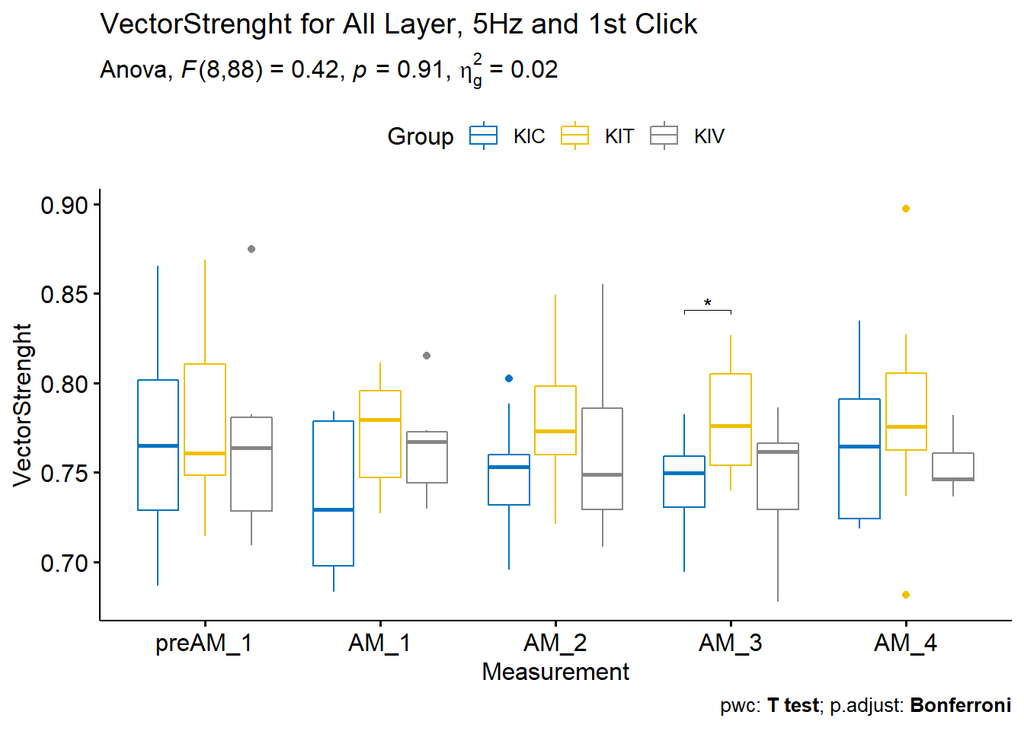

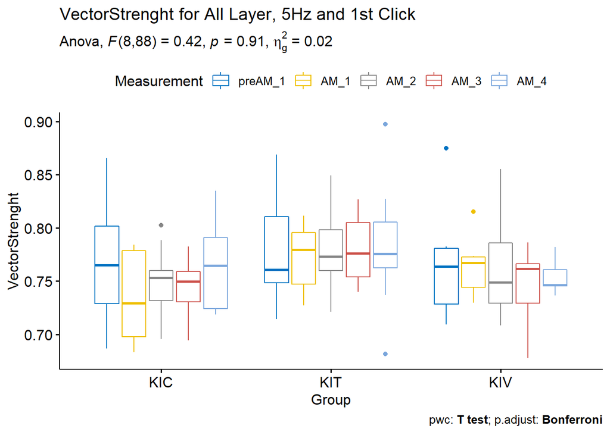

### I_II Layer

#### VectorStrenght

##### Assumptions Check

**===OUTLIERS===**

| Group | Measurement | Animal | VectorStrenght | is.outlier | is.extreme |
| --- | --- | --- | --- | --- | --- |
| KIT | preAM_1 | KIT03 | 0.741496 | TRUE | FALSE |
| KIC | AM_1 | KIC14 | 0.599458 | TRUE | FALSE |
| KIT | AM_3 | KIT05 | 0.656514 | TRUE | FALSE |
| KIV | AM_3 | KIV16 | 0.799411 | TRUE | TRUE |
| KIV | AM_4 | KIV16 | 0.797732 | TRUE | FALSE |

**===NORMALITY ASSUMPTION===**

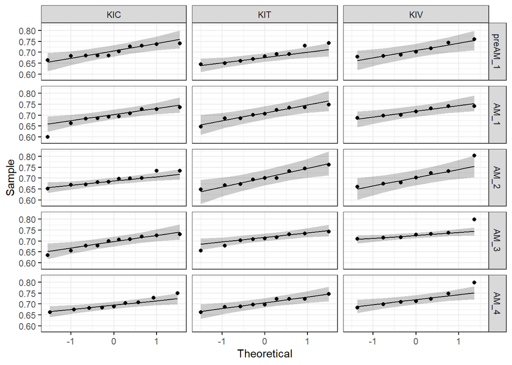

**===HOMOGENEITY OF VARIANCE ASSUMPTION===**

| Measurement | df1 | df2 | statistic | p |
| --- | --- | --- | --- | --- |
| preAM_1 | 2 | 23 | 0.025 | 0.975 |
| AM_1 | 2 | 23 | 0.359 | 0.702 |
| AM_2 | 2 | 23 | 0.817 | 0.454 |
| AM_3 | 2 | 23 | 0.241 | 0.788 |
| AM_4 | 2 | 22 | 0.119 | 0.888 |

##### Mixed ANOVA

| Effect | DFn | DFd | F | p | p..05 | ges |
| --- | --- | --- | --- | --- | --- | --- |
| Group | 2 | 22 | 2.315 | 0.122 |  | 0.084 |
| Measurement | 4 | 88 | 0.880 | 0.479 |  | 0.022 |
| Group:Measurement | 8 | 88 | 0.904 | 0.517 |  | 0.044 |

##### Post-hoc Tests

**===SIGNIFICANT TWO-WAY INTERACTION===**

**=EFFECT OF GROUP AT EACH MEASUREMENT=**

Measurement

Effect

DFn

DFd

p

p..05

ges

p.adj

preAM_1

Group

2

23

0.212

0.126

1.00

AM_1

Group

2

23

0.293

0.101

1.00

AM_2

Group

2

23

0.586

0.045

1.00

AM_3

Group

2

23

0.036

0.252

0.18

AM_4

Group

2

22

0.218

0.129

1.00

**=PAIRWISE COMPARISONS BETWEEN GROUP LEVELS=**

| Measurement | .y. | group1 | group2 | n1 | n2 | statistic | df | p | p.adj | p.adj.signif | effsize | magnitude |
| --- | --- | --- | --- | --- | --- | --- | --- | --- | --- | --- | --- | --- |
| preAM_1 | VectorStrenght | KIC | KIT | 10 | 10 | 1.374 | 15.549 | 0.189 | 0.567 | ns | 0.635 | moderate |
| preAM_1 | VectorStrenght | KIC | KIV | 10 | 7 | -0.475 | 11.847 | 0.644 | 1.000 | ns | -0.237 | small |
| preAM_1 | VectorStrenght | KIT | KIV | 10 | 7 | -1.619 | 13.413 | 0.129 | 0.387 | ns | -0.813 | large |
| AM_1 | VectorStrenght | KIC | KIT | 10 | 10 | -1.006 | 16.796 | 0.329 | 0.987 | ns | -0.460 | small |
| AM_1 | VectorStrenght | KIC | KIV | 10 | 7 | -1.672 | 14.463 | 0.116 | 0.348 | ns | -0.784 | moderate |
| AM_1 | VectorStrenght | KIT | KIV | 10 | 7 | -0.643 | 13.879 | 0.531 | 1.000 | ns | -0.317 | small |
| AM_2 | VectorStrenght | KIC | KIT | 10 | 10 | -0.694 | 14.393 | 0.499 | 1.000 | ns | -0.322 | small |
| AM_2 | VectorStrenght | KIC | KIV | 10 | 7 | -0.931 | 8.523 | 0.378 | 1.000 | ns | -0.480 | small |
| AM_2 | VectorStrenght | KIT | KIV | 10 | 7 | -0.382 | 10.957 | 0.710 | 1.000 | ns | -0.196 | negligible |
| AM_3 | VectorStrenght | KIC | KIT | 10 | 10 | -1.136 | 16.988 | 0.272 | 0.816 | ns | -0.520 | moderate |
| AM_3 | VectorStrenght | KIC | KIV | 10 | 7 | -2.699 | 13.477 | 0.018 | 0.053 | ns | -1.324 | large |
| AM_3 | VectorStrenght | KIT | KIV | 10 | 7 | -1.741 | 12.407 | 0.106 | 0.318 | ns | -0.882 | large |
| AM_4 | VectorStrenght | KIC | KIT | 9 | 9 | -0.592 | 15.957 | 0.562 | 1.000 | ns | -0.279 | small |
| AM_4 | VectorStrenght | KIC | KIV | 9 | 7 | -1.583 | 10.490 | 0.143 | 0.429 | ns | -0.814 | large |
| AM_4 | VectorStrenght | KIT | KIV | 9 | 7 | -1.163 | 10.109 | 0.271 | 0.813 | ns | -0.600 | moderate |

**=EFFECT OF MEASUREMENT AT EACH LEVEL OF GROUP=**

| Group | Effect | DFn | DFd | F | p | p..05 | ges | p.adj |
| --- | --- | --- | --- | --- | --- | --- | --- | --- |
| KIC | Measurement | 4 | 32 | 0.277 | 0.891 |  | 0.027 | 1.000 |
| KIT | Measurement | 4 | 32 | 1.272 | 0.301 |  | 0.085 | 0.903 |
| KIV | Measurement | 4 | 24 | 1.807 | 0.160 |  | 0.073 | 0.480 |

**=PAIRWISE COMPARISONS BETWEEN MEASUREMENTS AT EACH GROUP LEVELS=**

| Group | .y. | group1 | group2 | n1 | n2 | statistic | df | p | p.adj | p.adj.signif | effsize | magnitude |
| --- | --- | --- | --- | --- | --- | --- | --- | --- | --- | --- | --- | --- |
| KIC | VectorStrenght | preAM_1 | AM_1 | 9 | 9 | 0.753 | 8 | 0.473 | 1.000 | ns | 0.251 | small |
| KIC | VectorStrenght | preAM_1 | AM_2 | 9 | 9 | 0.787 | 8 | 0.454 | 1.000 | ns | 0.262 | small |
| KIC | VectorStrenght | preAM_1 | AM_3 | 9 | 9 | 0.611 | 8 | 0.558 | 1.000 | ns | 0.204 | small |
| KIC | VectorStrenght | preAM_1 | AM_4 | 9 | 9 | 0.569 | 8 | 0.585 | 1.000 | ns | 0.190 | negligible |
| KIC | VectorStrenght | AM_1 | AM_2 | 9 | 9 | -0.104 | 8 | 0.920 | 1.000 | ns | -0.035 | negligible |
| KIC | VectorStrenght | AM_1 | AM_3 | 9 | 9 | -0.224 | 8 | 0.828 | 1.000 | ns | -0.075 | negligible |
| KIC | VectorStrenght | AM_1 | AM_4 | 9 | 9 | -0.446 | 8 | 0.668 | 1.000 | ns | -0.149 | negligible |
| KIC | VectorStrenght | AM_2 | AM_3 | 9 | 9 | -0.173 | 8 | 0.867 | 1.000 | ns | -0.058 | negligible |
| KIC | VectorStrenght | AM_2 | AM_4 | 9 | 9 | -0.392 | 8 | 0.705 | 1.000 | ns | -0.131 | negligible |
| KIC | VectorStrenght | AM_3 | AM_4 | 9 | 9 | -0.179 | 8 | 0.862 | 1.000 | ns | -0.060 | negligible |
| KIT | VectorStrenght | preAM_1 | AM_1 | 9 | 9 | -2.305 | 8 | 0.050 | 0.501 | ns | -0.768 | moderate |
| KIT | VectorStrenght | preAM_1 | AM_2 | 9 | 9 | -1.084 | 8 | 0.310 | 1.000 | ns | -0.361 | small |
| KIT | VectorStrenght | preAM_1 | AM_3 | 9 | 9 | -2.174 | 8 | 0.061 | 0.614 | ns | -0.725 | moderate |
| KIT | VectorStrenght | preAM_1 | AM_4 | 9 | 9 | -1.761 | 8 | 0.116 | 1.000 | ns | -0.587 | moderate |
| KIT | VectorStrenght | AM_1 | AM_2 | 9 | 9 | 0.632 | 8 | 0.545 | 1.000 | ns | 0.211 | small |
| KIT | VectorStrenght | AM_1 | AM_3 | 9 | 9 | -0.097 | 8 | 0.925 | 1.000 | ns | -0.032 | negligible |
| KIT | VectorStrenght | AM_1 | AM_4 | 9 | 9 | 0.253 | 8 | 0.806 | 1.000 | ns | 0.084 | negligible |
| KIT | VectorStrenght | AM_2 | AM_3 | 9 | 9 | -0.456 | 8 | 0.661 | 1.000 | ns | -0.152 | negligible |
| KIT | VectorStrenght | AM_2 | AM_4 | 9 | 9 | -0.180 | 8 | 0.862 | 1.000 | ns | -0.060 | negligible |
| KIT | VectorStrenght | AM_3 | AM_4 | 9 | 9 | 0.398 | 8 | 0.701 | 1.000 | ns | 0.133 | negligible |
| KIV | VectorStrenght | preAM_1 | AM_1 | 7 | 7 | -0.493 | 6 | 0.640 | 1.000 | ns | -0.186 | negligible |
| KIV | VectorStrenght | preAM_1 | AM_2 | 7 | 7 | 0.009 | 6 | 0.993 | 1.000 | ns | 0.004 | negligible |
| KIV | VectorStrenght | preAM_1 | AM_3 | 7 | 7 | -2.477 | 6 | 0.048 | 0.480 | ns | -0.936 | large |
| KIV | VectorStrenght | preAM_1 | AM_4 | 7 | 7 | -1.050 | 6 | 0.334 | 1.000 | ns | -0.397 | small |
| KIV | VectorStrenght | AM_1 | AM_2 | 7 | 7 | 0.462 | 6 | 0.661 | 1.000 | ns | 0.174 | negligible |
| KIV | VectorStrenght | AM_1 | AM_3 | 7 | 7 | -1.936 | 6 | 0.101 | 1.000 | ns | -0.732 | moderate |
| KIV | VectorStrenght | AM_1 | AM_4 | 7 | 7 | -0.833 | 6 | 0.437 | 1.000 | ns | -0.315 | small |
| KIV | VectorStrenght | AM_2 | AM_3 | 7 | 7 | -2.301 | 6 | 0.061 | 0.610 | ns | -0.870 | large |
| KIV | VectorStrenght | AM_2 | AM_4 | 7 | 7 | -1.360 | 6 | 0.223 | 1.000 | ns | -0.514 | moderate |
| KIV | VectorStrenght | AM_3 | AM_4 | 7 | 7 | 1.298 | 6 | 0.242 | 1.000 | ns | 0.491 | small |

**===NON-SIGNIFICANT TWO-WAY INTERACTION===**

**=MAIN EFFECT OF MEASUREMENT=**

| .y. | group1 | group2 | n1 | n2 | statistic | df | p | p.adj | p.adj.signif |
| --- | --- | --- | --- | --- | --- | --- | --- | --- | --- |
| VectorStrenght | preAM_1 | AM_1 | 25 | 25 | -0.5652139 | 24 | 0.577 | 1 | ns |
| VectorStrenght | preAM_1 | AM_2 | 25 | 25 | -0.1928888 | 24 | 0.849 | 1 | ns |
| VectorStrenght | preAM_1 | AM_3 | 25 | 25 | -1.4141459 | 24 | 0.170 | 1 | ns |
| VectorStrenght | preAM_1 | AM_4 | 25 | 25 | -1.0520218 | 24 | 0.303 | 1 | ns |
| VectorStrenght | AM_1 | AM_2 | 25 | 25 | 0.4628736 | 24 | 0.648 | 1 | ns |
| VectorStrenght | AM_1 | AM_3 | 25 | 25 | -0.8803562 | 24 | 0.387 | 1 | ns |
| VectorStrenght | AM_1 | AM_4 | 25 | 25 | -0.4694492 | 24 | 0.643 | 1 | ns |
| VectorStrenght | AM_2 | AM_3 | 25 | 25 | -1.2917071 | 24 | 0.209 | 1 | ns |
| VectorStrenght | AM_2 | AM_4 | 25 | 25 | -0.8942456 | 24 | 0.380 | 1 | ns |
| VectorStrenght | AM_3 | AM_4 | 25 | 25 | 0.5925187 | 24 | 0.559 | 1 | ns |

**=MAIN EFFECT OF GROUP=**

.y.

group1

group2

n1

n2

p

p.signif

p.adj

p.adj.signif

VectorStrenght

KIC

KIT

49

49

0.35200

ns

1.00000

ns

VectorStrenght

KIC

KIV

49

35

0.00092

***

0.00276

VectorStrenght

KIT

KIV

49

35

0.01450

0.04360

##### Plots

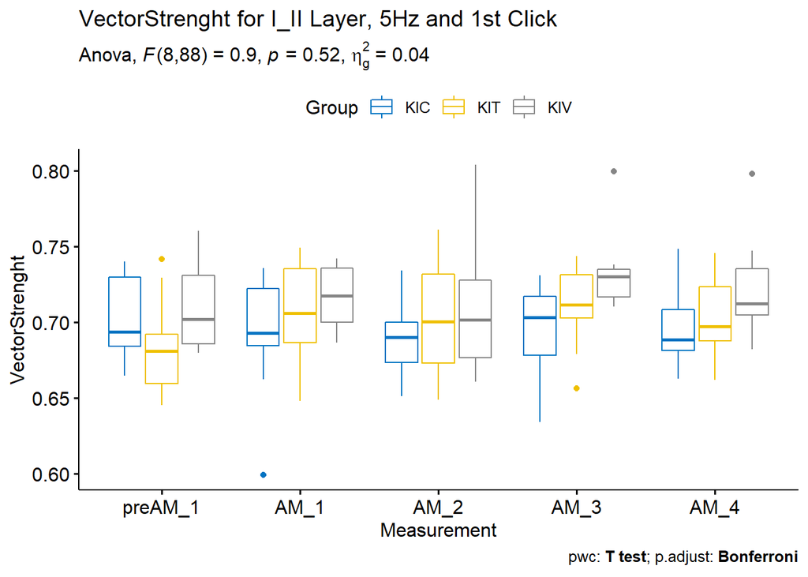

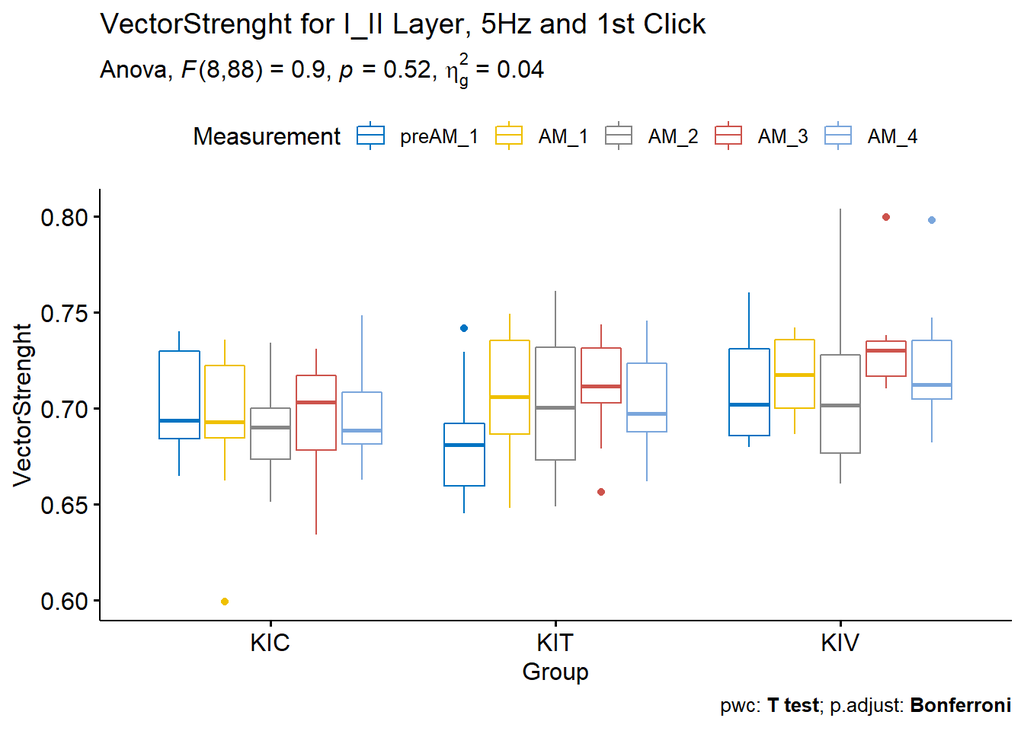

### IV Layer

#### VectorStrenght

##### Assumptions Check

**===OUTLIERS===**

| Group | Measurement | Animal | VectorStrenght | is.outlier | is.extreme |
| --- | --- | --- | --- | --- | --- |
| KIT | AM_1 | KIT04 | 0.646487 | TRUE | FALSE |

**===NORMALITY ASSUMPTION===**

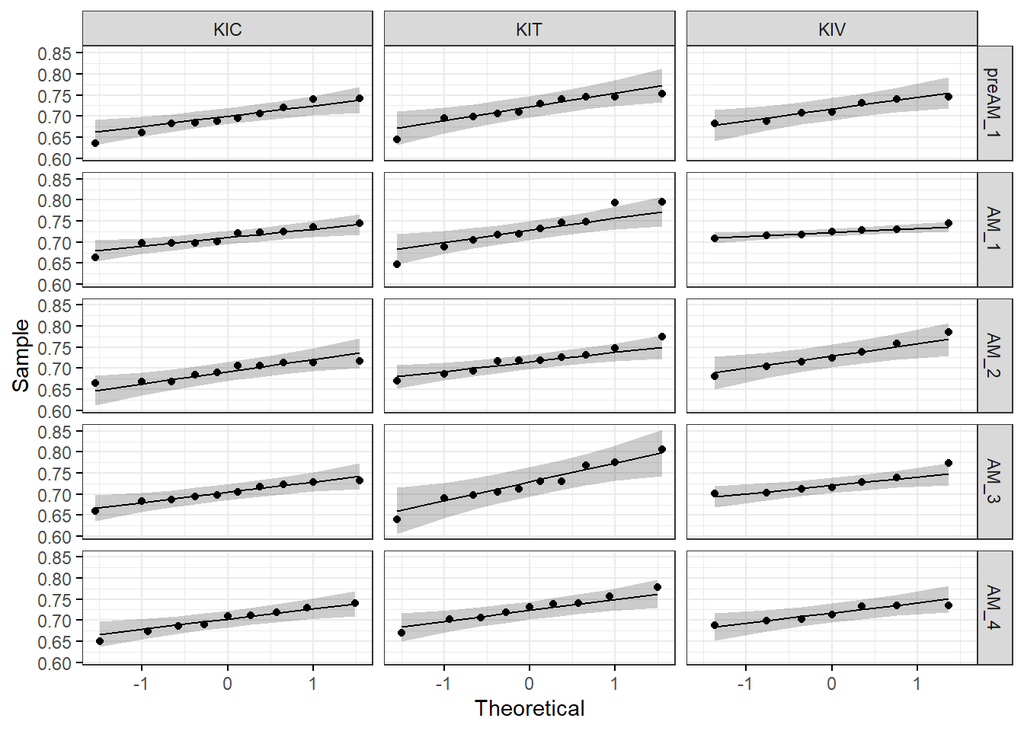

**===HOMOGENEITY OF VARIANCE ASSUMPTION===**

| Measurement | df1 | df2 | statistic | p |
| --- | --- | --- | --- | --- |
| preAM_1 | 2 | 24 | 0.257 | 0.776 |
| AM_1 | 2 | 24 | 3.556 | 0.044 |
| AM_2 | 2 | 24 | 0.438 | 0.650 |
| AM_3 | 2 | 24 | 2.348 | 0.117 |
| AM_4 | 2 | 22 | 0.499 | 0.614 |

##### Mixed ANOVA

Effect

DFn

DFd

F

p

p..05

ges

Group

2

22

5.304

0.013

0.174

Measurement

4

88

1.076

0.373

0.027

Group:Measurement

8

88

0.315

0.959

0.016

##### Post-hoc Tests

**===SIGNIFICANT TWO-WAY INTERACTION===**

**=EFFECT OF GROUP AT EACH MEASUREMENT=**

Measurement

Effect

DFn

DFd

p

p..05

ges

p.adj

preAM_1

Group

2

24

0.287

0.099

1.00

AM_1

Group

2

24

0.423

0.069

1.00

AM_2

Group

2

24

0.036

0.241

0.18

AM_3

Group

2

24

0.290

0.098

1.00

AM_4

Group

2

22

0.168

0.150

0.84

**=PAIRWISE COMPARISONS BETWEEN GROUP LEVELS=**

| Measurement | .y. | group1 | group2 | n1 | n2 | statistic | df | p | p.adj | p.adj.signif | effsize | magnitude |
| --- | --- | --- | --- | --- | --- | --- | --- | --- | --- | --- | --- | --- |
| preAM_1 | VectorStrenght | KIC | KIT | 10 | 10 | -1.405 | 17.999 | 0.177 | 0.531 | ns | -0.628 | moderate |
| preAM_1 | VectorStrenght | KIC | KIV | 10 | 7 | -1.371 | 14.872 | 0.191 | 0.573 | ns | -0.659 | moderate |
| preAM_1 | VectorStrenght | KIT | KIV | 10 | 7 | 0.112 | 14.887 | 0.912 | 1.000 | ns | 0.054 | negligible |
| AM_1 | VectorStrenght | KIC | KIT | 10 | 10 | -1.138 | 13.677 | 0.275 | 0.825 | ns | -0.509 | moderate |
| AM_1 | VectorStrenght | KIC | KIV | 10 | 7 | -1.597 | 13.825 | 0.133 | 0.399 | ns | -0.744 | moderate |
| AM_1 | VectorStrenght | KIT | KIV | 10 | 7 | 0.293 | 10.680 | 0.775 | 1.000 | ns | 0.133 | negligible |
| AM_2 | VectorStrenght | KIC | KIT | 10 | 10 | -2.200 | 15.898 | 0.043 | 0.129 | ns | -0.984 | large |
| AM_2 | VectorStrenght | KIC | KIV | 10 | 7 | -2.477 | 8.942 | 0.035 | 0.106 | ns | -1.272 | large |
| AM_2 | VectorStrenght | KIT | KIV | 10 | 7 | -0.676 | 11.787 | 0.512 | 1.000 | ns | -0.337 | small |
| AM_3 | VectorStrenght | KIC | KIT | 10 | 10 | -1.352 | 12.802 | 0.200 | 0.600 | ns | -0.605 | moderate |
| AM_3 | VectorStrenght | KIC | KIV | 10 | 7 | -1.857 | 12.144 | 0.088 | 0.263 | ns | -0.923 | large |
| AM_3 | VectorStrenght | KIT | KIV | 10 | 7 | 0.036 | 14.157 | 0.972 | 1.000 | ns | 0.017 | negligible |
| AM_4 | VectorStrenght | KIC | KIT | 9 | 9 | -1.797 | 15.774 | 0.092 | 0.275 | ns | -0.847 | large |
| AM_4 | VectorStrenght | KIC | KIV | 9 | 7 | -1.179 | 13.800 | 0.258 | 0.774 | ns | -0.580 | moderate |
| AM_4 | VectorStrenght | KIT | KIV | 9 | 7 | 0.898 | 13.299 | 0.385 | 1.000 | ns | 0.439 | small |

**=EFFECT OF MEASUREMENT AT EACH LEVEL OF GROUP=**

| Group | Effect | DFn | DFd | F | p | p..05 | ges | p.adj |
| --- | --- | --- | --- | --- | --- | --- | --- | --- |
| KIC | Measurement | 4 | 32 | 0.439 | 0.779 |  | 0.035 | 1 |
| KIT | Measurement | 4 | 32 | 0.785 | 0.544 |  | 0.041 | 1 |
| KIV | Measurement | 4 | 24 | 0.551 | 0.700 |  | 0.061 | 1 |

**=PAIRWISE COMPARISONS BETWEEN MEASUREMENTS AT EACH GROUP LEVELS=**

| Group | .y. | group1 | group2 | n1 | n2 | statistic | df | p | p.adj | p.adj.signif | effsize | magnitude |
| --- | --- | --- | --- | --- | --- | --- | --- | --- | --- | --- | --- | --- |
| KIC | VectorStrenght | preAM_1 | AM_1 | 9 | 9 | -0.956 | 8 | 0.367 | 1.00 | ns | -0.319 | small |
| KIC | VectorStrenght | preAM_1 | AM_2 | 9 | 9 | -0.038 | 8 | 0.971 | 1.00 | ns | -0.013 | negligible |
| KIC | VectorStrenght | preAM_1 | AM_3 | 9 | 9 | -0.601 | 8 | 0.565 | 1.00 | ns | -0.200 | small |
| KIC | VectorStrenght | preAM_1 | AM_4 | 9 | 9 | -0.390 | 8 | 0.706 | 1.00 | ns | -0.130 | negligible |
| KIC | VectorStrenght | AM_1 | AM_2 | 9 | 9 | 1.204 | 8 | 0.263 | 1.00 | ns | 0.401 | small |
| KIC | VectorStrenght | AM_1 | AM_3 | 9 | 9 | 0.387 | 8 | 0.709 | 1.00 | ns | 0.129 | negligible |
| KIC | VectorStrenght | AM_1 | AM_4 | 9 | 9 | 0.634 | 8 | 0.544 | 1.00 | ns | 0.211 | small |
| KIC | VectorStrenght | AM_2 | AM_3 | 9 | 9 | -0.880 | 8 | 0.405 | 1.00 | ns | -0.293 | small |
| KIC | VectorStrenght | AM_2 | AM_4 | 9 | 9 | -0.419 | 8 | 0.686 | 1.00 | ns | -0.140 | negligible |
| KIC | VectorStrenght | AM_3 | AM_4 | 9 | 9 | 0.349 | 8 | 0.736 | 1.00 | ns | 0.116 | negligible |
| KIT | VectorStrenght | preAM_1 | AM_1 | 9 | 9 | -1.403 | 8 | 0.198 | 1.00 | ns | -0.468 | small |
| KIT | VectorStrenght | preAM_1 | AM_2 | 9 | 9 | 0.487 | 8 | 0.639 | 1.00 | ns | 0.162 | negligible |
| KIT | VectorStrenght | preAM_1 | AM_3 | 9 | 9 | -0.712 | 8 | 0.496 | 1.00 | ns | -0.237 | small |
| KIT | VectorStrenght | preAM_1 | AM_4 | 9 | 9 | -0.198 | 8 | 0.848 | 1.00 | ns | -0.066 | negligible |
| KIT | VectorStrenght | AM_1 | AM_2 | 9 | 9 | 2.029 | 8 | 0.077 | 0.77 | ns | 0.676 | moderate |
| KIT | VectorStrenght | AM_1 | AM_3 | 9 | 9 | 0.257 | 8 | 0.804 | 1.00 | ns | 0.086 | negligible |
| KIT | VectorStrenght | AM_1 | AM_4 | 9 | 9 | 0.881 | 8 | 0.404 | 1.00 | ns | 0.294 | small |
| KIT | VectorStrenght | AM_2 | AM_3 | 9 | 9 | -1.255 | 8 | 0.245 | 1.00 | ns | -0.418 | small |
| KIT | VectorStrenght | AM_2 | AM_4 | 9 | 9 | -0.452 | 8 | 0.663 | 1.00 | ns | -0.151 | negligible |
| KIT | VectorStrenght | AM_3 | AM_4 | 9 | 9 | 0.690 | 8 | 0.510 | 1.00 | ns | 0.230 | small |
| KIV | VectorStrenght | preAM_1 | AM_1 | 7 | 7 | -0.799 | 6 | 0.455 | 1.00 | ns | -0.302 | small |
| KIV | VectorStrenght | preAM_1 | AM_2 | 7 | 7 | -1.043 | 6 | 0.337 | 1.00 | ns | -0.394 | small |
| KIV | VectorStrenght | preAM_1 | AM_3 | 7 | 7 | -0.761 | 6 | 0.475 | 1.00 | ns | -0.288 | small |
| KIV | VectorStrenght | preAM_1 | AM_4 | 7 | 7 | -0.030 | 6 | 0.977 | 1.00 | ns | -0.011 | negligible |
| KIV | VectorStrenght | AM_1 | AM_2 | 7 | 7 | -0.325 | 6 | 0.756 | 1.00 | ns | -0.123 | negligible |
| KIV | VectorStrenght | AM_1 | AM_3 | 7 | 7 | -0.019 | 6 | 0.985 | 1.00 | ns | -0.007 | negligible |
| KIV | VectorStrenght | AM_1 | AM_4 | 7 | 7 | 1.514 | 6 | 0.181 | 1.00 | ns | 0.572 | moderate |
| KIV | VectorStrenght | AM_2 | AM_3 | 7 | 7 | 0.565 | 6 | 0.592 | 1.00 | ns | 0.214 | small |
| KIV | VectorStrenght | AM_2 | AM_4 | 7 | 7 | 0.878 | 6 | 0.414 | 1.00 | ns | 0.332 | small |
| KIV | VectorStrenght | AM_3 | AM_4 | 7 | 7 | 0.812 | 6 | 0.448 | 1.00 | ns | 0.307 | small |

**===NON-SIGNIFICANT TWO-WAY INTERACTION===**

**=MAIN EFFECT OF MEASUREMENT=**

| .y. | group1 | group2 | n1 | n2 | statistic | df | p | p.adj | p.adj.signif |
| --- | --- | --- | --- | --- | --- | --- | --- | --- | --- |
| VectorStrenght | preAM_1 | AM_1 | 25 | 25 | -1.8706023 | 24 | 0.074 | 0.736 | ns |
| VectorStrenght | preAM_1 | AM_2 | 25 | 25 | -0.5246147 | 24 | 0.605 | 1.000 | ns |
| VectorStrenght | preAM_1 | AM_3 | 25 | 25 | -1.2180721 | 24 | 0.235 | 1.000 | ns |
| VectorStrenght | preAM_1 | AM_4 | 25 | 25 | -0.3976034 | 24 | 0.694 | 1.000 | ns |
| VectorStrenght | AM_1 | AM_2 | 25 | 25 | 1.4577810 | 24 | 0.158 | 1.000 | ns |
| VectorStrenght | AM_1 | AM_3 | 25 | 25 | 0.3981881 | 24 | 0.694 | 1.000 | ns |
| VectorStrenght | AM_1 | AM_4 | 25 | 25 | 1.5166868 | 24 | 0.142 | 1.000 | ns |
| VectorStrenght | AM_2 | AM_3 | 25 | 25 | -1.1807304 | 24 | 0.249 | 1.000 | ns |
| VectorStrenght | AM_2 | AM_4 | 25 | 25 | 0.0077970 | 24 | 0.994 | 1.000 | ns |
| VectorStrenght | AM_3 | AM_4 | 25 | 25 | 1.1045023 | 24 | 0.280 | 1.000 | ns |

**=MAIN EFFECT OF GROUP=**

| .y. | group1 | group2 | n1 | n2 | p | p.signif | p.adj | p.adj.signif |
| --- | --- | --- | --- | --- | --- | --- | --- | --- |
| VectorStrenght | KIC | KIT | 49 | 49 | 0.000302 | *** | 0.000905 | *** |
| VectorStrenght | KIC | KIV | 49 | 35 | 0.001810 | ** | 0.005440 | ** |
| VectorStrenght | KIT | KIV | 49 | 35 | 0.837000 | ns | 1.000000 | ns |

##### Plots

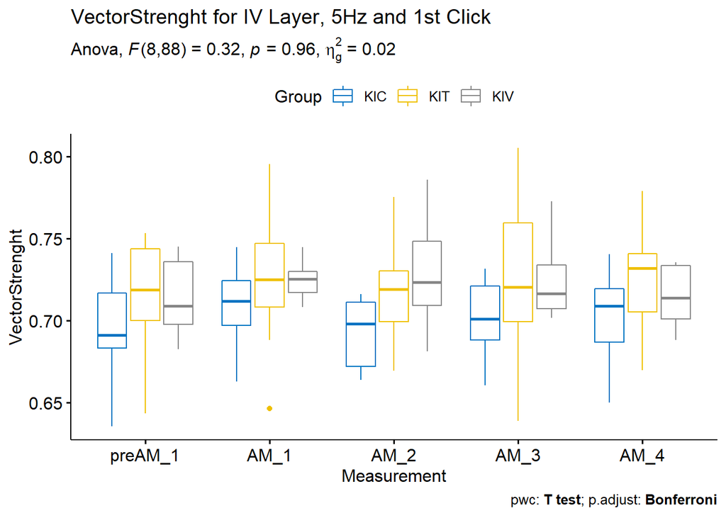

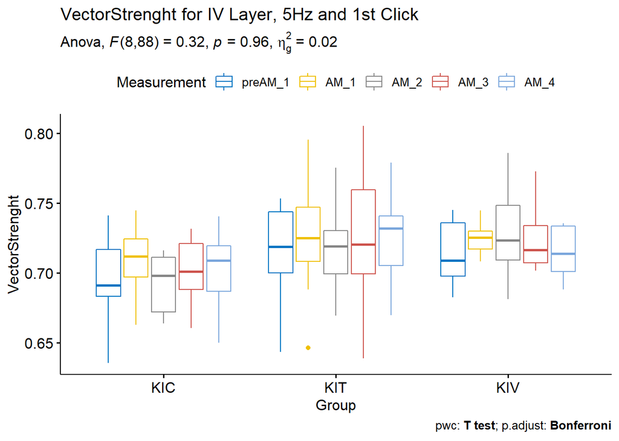

### V Layer

#### VectorStrenght

##### Assumptions Check

**===OUTLIERS===**

| Group | Measurement | Animal | VectorStrenght | is.outlier | is.extreme |
| --- | --- | --- | --- | --- | --- |
| KIC | preAM_1 | KIC04 | 0.602642 | TRUE | TRUE |
| KIC | preAM_1 | KIC10 | 0.787852 | TRUE | FALSE |
| KIC | AM_2 | KIC10 | 0.729455 | TRUE | FALSE |
| KIT | AM_3 | KIT03 | 0.758874 | TRUE | FALSE |
| KIT | AM_3 | KIT04 | 0.642573 | TRUE | FALSE |
| KIT | AM_3 | KIT05 | 0.646523 | TRUE | FALSE |
| KIV | AM_4 | KIV09 | 0.633510 | TRUE | TRUE |

**===NORMALITY ASSUMPTION===**

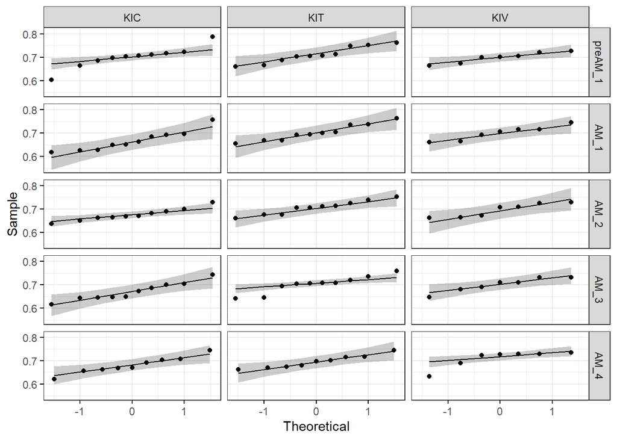

**===HOMOGENEITY OF VARIANCE ASSUMPTION===**

| Measurement | df1 | df2 | statistic | p |
| --- | --- | --- | --- | --- |
| preAM_1 | 2 | 24 | 0.486 | 0.621 |
| AM_1 | 2 | 24 | 0.370 | 0.695 |
| AM_2 | 2 | 24 | 0.144 | 0.866 |
| AM_3 | 2 | 24 | 0.305 | 0.740 |
| AM_4 | 2 | 22 | 0.125 | 0.883 |

##### Mixed ANOVA

| Effect | DFn | DFd | F | p | p..05 | ges |
| --- | --- | --- | --- | --- | --- | --- |
| Group | 2 | 22 | 2.234 | 0.131 |  | 0.111 |
| Measurement | 4 | 88 | 1.418 | 0.235 |  | 0.024 |
| Group:Measurement | 8 | 88 | 1.023 | 0.425 |  | 0.034 |

##### Post-hoc Tests

**===SIGNIFICANT TWO-WAY INTERACTION===**

**=EFFECT OF GROUP AT EACH MEASUREMENT=**

| Measurement | Effect | DFn | DFd | p | p..05 | ges | p.adj |
| --- | --- | --- | --- | --- | --- | --- | --- |
| preAM_1 | Group | 2 | 24 | 0.746 |  | 0.024 | 1.000 |
| AM_1 | Group | 2 | 24 | 0.076 |  | 0.193 | 0.380 |
| AM_2 | Group | 2 | 24 | 0.062 |  | 0.206 | 0.310 |
| AM_3 | Group | 2 | 24 | 0.113 |  | 0.166 | 0.565 |
| AM_4 | Group | 2 | 22 | 0.233 |  | 0.124 | 1.000 |

**=PAIRWISE COMPARISONS BETWEEN GROUP LEVELS=**

| Measurement | .y. | group1 | group2 | n1 | n2 | statistic | df | p | p.adj | p.adj.signif | effsize | magnitude |
| --- | --- | --- | --- | --- | --- | --- | --- | --- | --- | --- | --- | --- |
| preAM_1 | VectorStrenght | KIC | KIT | 10 | 10 | -0.598 | 16.594 | 0.558 | 1.000 | ns | -0.267 | small |
| preAM_1 | VectorStrenght | KIC | KIV | 10 | 7 | 0.065 | 13.760 | 0.949 | 1.000 | ns | 0.030 | negligible |
| preAM_1 | VectorStrenght | KIT | KIV | 10 | 7 | 0.869 | 14.978 | 0.398 | 1.000 | ns | 0.413 | small |
| AM_1 | VectorStrenght | KIC | KIT | 10 | 10 | -2.075 | 17.295 | 0.053 | 0.160 | ns | -0.928 | large |
| AM_1 | VectorStrenght | KIC | KIV | 10 | 7 | -1.921 | 14.982 | 0.074 | 0.222 | ns | -0.918 | large |
| AM_1 | VectorStrenght | KIT | KIV | 10 | 7 | 0.138 | 14.173 | 0.892 | 1.000 | ns | 0.067 | negligible |
| AM_2 | VectorStrenght | KIC | KIT | 10 | 10 | -2.490 | 17.819 | 0.023 | 0.069 | ns | -1.114 | large |
| AM_2 | VectorStrenght | KIC | KIV | 10 | 7 | -1.467 | 12.330 | 0.168 | 0.504 | ns | -0.728 | moderate |
| AM_2 | VectorStrenght | KIT | KIV | 10 | 7 | 0.767 | 13.222 | 0.457 | 1.000 | ns | 0.377 | small |
| AM_3 | VectorStrenght | KIC | KIT | 10 | 10 | -1.929 | 17.949 | 0.070 | 0.209 | ns | -0.863 | large |
| AM_3 | VectorStrenght | KIC | KIV | 10 | 7 | -1.765 | 14.655 | 0.098 | 0.295 | ns | -0.853 | large |
| AM_3 | VectorStrenght | KIT | KIV | 10 | 7 | 0.165 | 14.380 | 0.871 | 1.000 | ns | 0.080 | negligible |
| AM_4 | VectorStrenght | KIC | KIT | 9 | 9 | -1.034 | 14.924 | 0.318 | 0.954 | ns | -0.487 | small |
| AM_4 | VectorStrenght | KIC | KIV | 9 | 7 | -1.600 | 12.801 | 0.134 | 0.402 | ns | -0.808 | large |
| AM_4 | VectorStrenght | KIT | KIV | 9 | 7 | -0.837 | 10.662 | 0.421 | 1.000 | ns | -0.430 | small |

**=EFFECT OF MEASUREMENT AT EACH LEVEL OF GROUP=**

| Group | Effect | DFn | DFd | F | p | p..05 | ges | p.adj |
| --- | --- | --- | --- | --- | --- | --- | --- | --- |
| KIC | Measurement | 4 | 32 | 1.416 | 0.251 |  | 0.082 | 0.753 |
| KIT | Measurement | 4 | 32 | 1.461 | 0.237 |  | 0.048 | 0.711 |
| KIV | Measurement | 4 | 24 | 0.684 | 0.610 |  | 0.027 | 1.000 |

**=PAIRWISE COMPARISONS BETWEEN MEASUREMENTS AT EACH GROUP LEVELS=**

| Group | .y. | group1 | group2 | n1 | n2 | statistic | df | p | p.adj | p.adj.signif | effsize | magnitude |
| --- | --- | --- | --- | --- | --- | --- | --- | --- | --- | --- | --- | --- |
| KIC | VectorStrenght | preAM_1 | AM_1 | 9 | 9 | 2.614 | 8 | 0.031 | 0.309 | ns | 0.871 | large |
| KIC | VectorStrenght | preAM_1 | AM_2 | 9 | 9 | 2.077 | 8 | 0.071 | 0.714 | ns | 0.692 | moderate |
| KIC | VectorStrenght | preAM_1 | AM_3 | 9 | 9 | 1.604 | 8 | 0.147 | 1.000 | ns | 0.535 | moderate |
| KIC | VectorStrenght | preAM_1 | AM_4 | 9 | 9 | 1.036 | 8 | 0.331 | 1.000 | ns | 0.345 | small |
| KIC | VectorStrenght | AM_1 | AM_2 | 9 | 9 | -0.784 | 8 | 0.455 | 1.000 | ns | -0.261 | small |
| KIC | VectorStrenght | AM_1 | AM_3 | 9 | 9 | -0.540 | 8 | 0.604 | 1.000 | ns | -0.180 | negligible |
| KIC | VectorStrenght | AM_1 | AM_4 | 9 | 9 | -0.571 | 8 | 0.584 | 1.000 | ns | -0.190 | negligible |
| KIC | VectorStrenght | AM_2 | AM_3 | 9 | 9 | 0.206 | 8 | 0.842 | 1.000 | ns | 0.069 | negligible |
| KIC | VectorStrenght | AM_2 | AM_4 | 9 | 9 | -0.295 | 8 | 0.776 | 1.000 | ns | -0.098 | negligible |
| KIC | VectorStrenght | AM_3 | AM_4 | 9 | 9 | -0.363 | 8 | 0.726 | 1.000 | ns | -0.121 | negligible |
| KIT | VectorStrenght | preAM_1 | AM_1 | 9 | 9 | 1.115 | 8 | 0.297 | 1.000 | ns | 0.372 | small |
| KIT | VectorStrenght | preAM_1 | AM_2 | 9 | 9 | 1.234 | 8 | 0.252 | 1.000 | ns | 0.411 | small |
| KIT | VectorStrenght | preAM_1 | AM_3 | 9 | 9 | 1.275 | 8 | 0.238 | 1.000 | ns | 0.425 | small |
| KIT | VectorStrenght | preAM_1 | AM_4 | 9 | 9 | 2.832 | 8 | 0.022 | 0.221 | ns | 0.944 | large |
| KIT | VectorStrenght | AM_1 | AM_2 | 9 | 9 | -0.115 | 8 | 0.911 | 1.000 | ns | -0.038 | negligible |
| KIT | VectorStrenght | AM_1 | AM_3 | 9 | 9 | -0.707 | 8 | 0.500 | 1.000 | ns | -0.236 | small |
| KIT | VectorStrenght | AM_1 | AM_4 | 9 | 9 | 0.878 | 8 | 0.406 | 1.000 | ns | 0.293 | small |
| KIT | VectorStrenght | AM_2 | AM_3 | 9 | 9 | -0.518 | 8 | 0.619 | 1.000 | ns | -0.173 | negligible |
| KIT | VectorStrenght | AM_2 | AM_4 | 9 | 9 | 1.121 | 8 | 0.295 | 1.000 | ns | 0.374 | small |
| KIT | VectorStrenght | AM_3 | AM_4 | 9 | 9 | 1.900 | 8 | 0.094 | 0.939 | ns | 0.633 | moderate |
| KIV | VectorStrenght | preAM_1 | AM_1 | 7 | 7 | -0.168 | 6 | 0.872 | 1.000 | ns | -0.064 | negligible |
| KIV | VectorStrenght | preAM_1 | AM_2 | 7 | 7 | 0.333 | 6 | 0.750 | 1.000 | ns | 0.126 | negligible |
| KIV | VectorStrenght | preAM_1 | AM_3 | 7 | 7 | -0.169 | 6 | 0.871 | 1.000 | ns | -0.064 | negligible |
| KIV | VectorStrenght | preAM_1 | AM_4 | 7 | 7 | -1.310 | 6 | 0.238 | 1.000 | ns | -0.495 | small |
| KIV | VectorStrenght | AM_1 | AM_2 | 7 | 7 | 0.747 | 6 | 0.483 | 1.000 | ns | 0.282 | small |
| KIV | VectorStrenght | AM_1 | AM_3 | 7 | 7 | 0.042 | 6 | 0.968 | 1.000 | ns | 0.016 | negligible |
| KIV | VectorStrenght | AM_1 | AM_4 | 7 | 7 | -0.760 | 6 | 0.476 | 1.000 | ns | -0.287 | small |
| KIV | VectorStrenght | AM_2 | AM_3 | 7 | 7 | -0.806 | 6 | 0.451 | 1.000 | ns | -0.305 | small |
| KIV | VectorStrenght | AM_2 | AM_4 | 7 | 7 | -1.420 | 6 | 0.205 | 1.000 | ns | -0.537 | moderate |
| KIV | VectorStrenght | AM_3 | AM_4 | 7 | 7 | -1.219 | 6 | 0.269 | 1.000 | ns | -0.461 | small |

**===NON-SIGNIFICANT TWO-WAY INTERACTION===**

**=MAIN EFFECT OF MEASUREMENT=**

| .y. | group1 | group2 | n1 | n2 | statistic | df | p | p.adj | p.adj.signif |
| --- | --- | --- | --- | --- | --- | --- | --- | --- | --- |
| VectorStrenght | preAM_1 | AM_1 | 25 | 25 | 2.2173142 | 24 | 0.036 | 0.363 | ns |
| VectorStrenght | preAM_1 | AM_2 | 25 | 25 | 2.2920243 | 24 | 0.031 | 0.310 | ns |
| VectorStrenght | preAM_1 | AM_3 | 25 | 25 | 1.6514966 | 24 | 0.112 | 1.000 | ns |
| VectorStrenght | preAM_1 | AM_4 | 25 | 25 | 1.4208697 | 24 | 0.168 | 1.000 | ns |
| VectorStrenght | AM_1 | AM_2 | 25 | 25 | -0.3030476 | 24 | 0.764 | 1.000 | ns |
| VectorStrenght | AM_1 | AM_3 | 25 | 25 | -0.8126793 | 24 | 0.424 | 1.000 | ns |
| VectorStrenght | AM_1 | AM_4 | 25 | 25 | -0.4745354 | 24 | 0.639 | 1.000 | ns |
| VectorStrenght | AM_2 | AM_3 | 25 | 25 | -0.4281619 | 24 | 0.672 | 1.000 | ns |
| VectorStrenght | AM_2 | AM_4 | 25 | 25 | -0.3639220 | 24 | 0.719 | 1.000 | ns |
| VectorStrenght | AM_3 | AM_4 | 25 | 25 | 0.0045512 | 24 | 0.996 | 1.000 | ns |

**=MAIN EFFECT OF GROUP=**

.y.

group1

group2

n1

n2

p

p.signif

p.adj

p.adj.signif

VectorStrenght

KIC

KIT

49

49

0.000311

***

0.000934

***

VectorStrenght

KIC

KIV

49

35

0.003390

0.010200

VectorStrenght

KIT

KIV

49

35

0.692000

ns

1.000000

ns

##### Plots

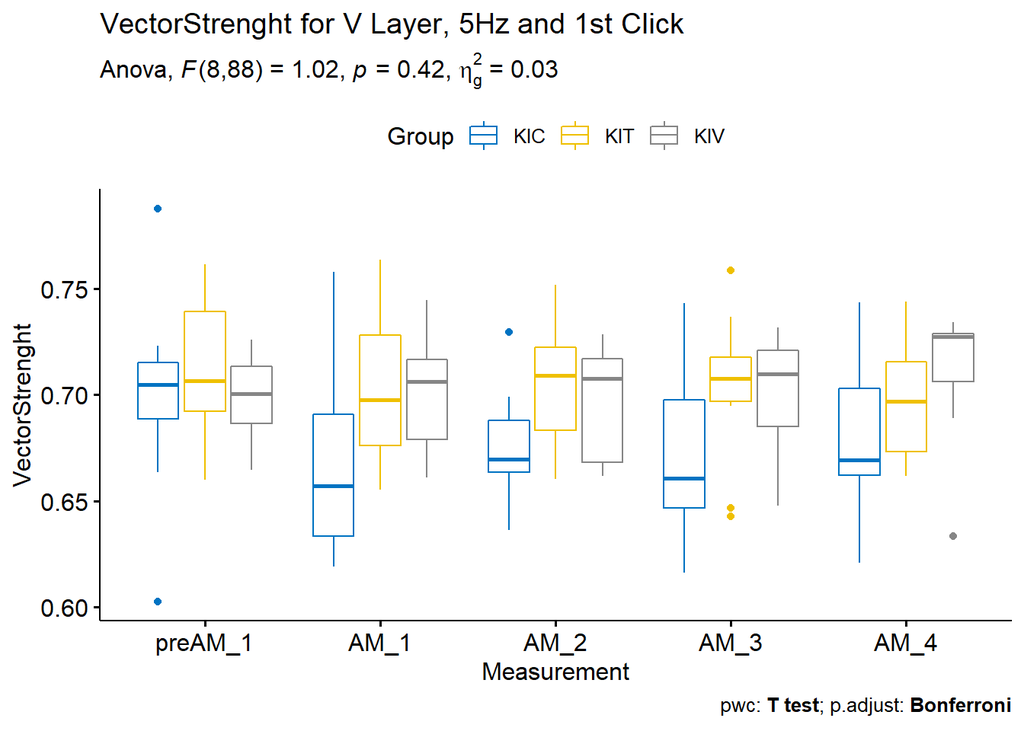

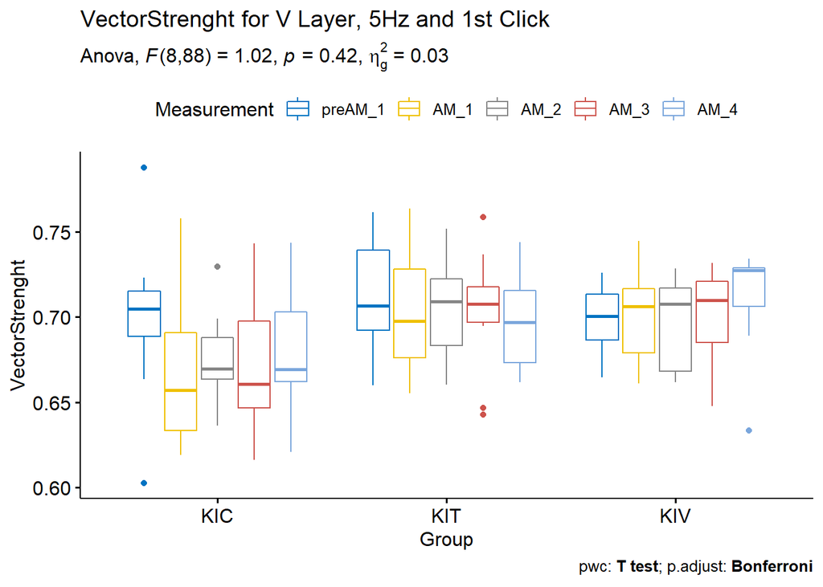

### VI Layer

#### VectorStrenght

##### Assumptions Check

**===OUTLIERS===**

| Group | Measurement | Animal | VectorStrenght | is.outlier | is.extreme |
| --- | --- | --- | --- | --- | --- |
| KIC | AM_1 | KIC14 | 0.784655 | TRUE | FALSE |
| KIC | AM_2 | KIC04 | 0.757297 | TRUE | FALSE |
| KIT | AM_2 | KIT01 | 0.760129 | TRUE | FALSE |
| KIV | AM_3 | KIV09 | 0.670425 | TRUE | FALSE |
| KIC | AM_4 | KIC02 | 0.733675 | TRUE | FALSE |

**===NORMALITY ASSUMPTION===**

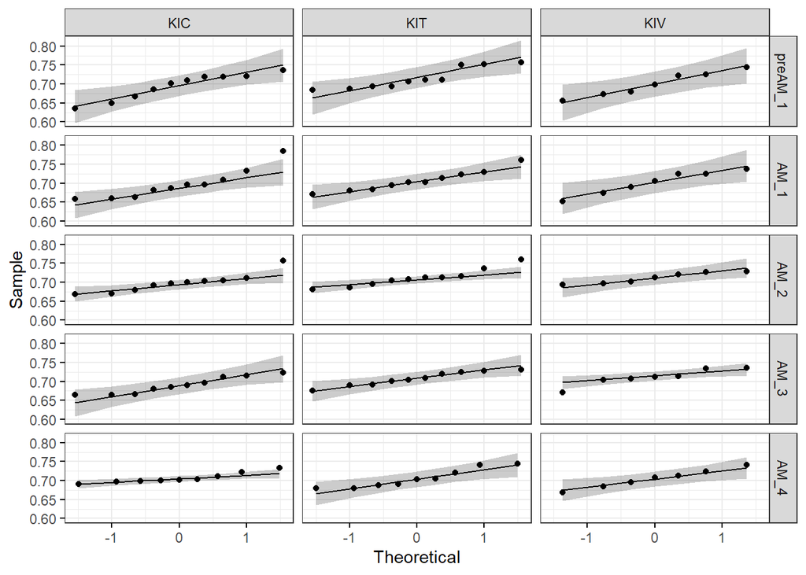

**===HOMOGENEITY OF VARIANCE ASSUMPTION===**

| Measurement | df1 | df2 | statistic | p |
| --- | --- | --- | --- | --- |
| preAM_1 | 2 | 24 | 0.185 | 0.832 |
| AM_1 | 2 | 24 | 0.270 | 0.766 |
| AM_2 | 2 | 24 | 0.242 | 0.787 |
| AM_3 | 2 | 24 | 0.217 | 0.806 |
| AM_4 | 2 | 22 | 1.556 | 0.233 |

##### Mixed ANOVA

| Effect | DFn | DFd | F | p | p..05 | ges |
| --- | --- | --- | --- | --- | --- | --- |
| Group | 2 | 22 | 1.315 | 0.289 |  | 0.049 |
| Measurement | 4 | 88 | 0.299 | 0.878 |  | 0.008 |
| Group:Measurement | 8 | 88 | 0.692 | 0.697 |  | 0.035 |

##### Post-hoc Tests

**===SIGNIFICANT TWO-WAY INTERACTION===**

**=EFFECT OF GROUP AT EACH MEASUREMENT=**

| Measurement | Effect | DFn | DFd | p | p..05 | ges | p.adj |
| --- | --- | --- | --- | --- | --- | --- | --- |
| preAM_1 | Group | 2 | 24 | 0.344 |  | 0.085000 | 1.000 |
| AM_1 | Group | 2 | 24 | 0.807 |  | 0.018000 | 1.000 |
| AM_2 | Group | 2 | 24 | 0.355 |  | 0.083000 | 1.000 |
| AM_3 | Group | 2 | 24 | 0.085 |  | 0.186000 | 0.425 |
| AM_4 | Group | 2 | 22 | 0.993 |  | 0.000653 | 1.000 |

**=PAIRWISE COMPARISONS BETWEEN GROUP LEVELS=**

| Measurement | .y. | group1 | group2 | n1 | n2 | statistic | df | p | p.adj | p.adj.signif | effsize | magnitude |
| --- | --- | --- | --- | --- | --- | --- | --- | --- | --- | --- | --- | --- |
| preAM_1 | VectorStrenght | KIC | KIT | 10 | 10 | -1.463 | 17.469 | 0.161 | 0.483 | ns | -0.654 | moderate |
| preAM_1 | VectorStrenght | KIC | KIV | 10 | 7 | -0.331 | 13.480 | 0.745 | 1.000 | ns | -0.163 | negligible |
| preAM_1 | VectorStrenght | KIT | KIV | 10 | 7 | 0.995 | 11.934 | 0.339 | 1.000 | ns | 0.496 | small |
| AM_1 | VectorStrenght | KIC | KIT | 10 | 10 | -0.643 | 16.045 | 0.530 | 1.000 | ns | -0.287 | small |
| AM_1 | VectorStrenght | KIC | KIV | 10 | 7 | -0.241 | 14.703 | 0.813 | 1.000 | ns | -0.116 | negligible |
| AM_1 | VectorStrenght | KIT | KIV | 10 | 7 | 0.387 | 11.955 | 0.706 | 1.000 | ns | 0.193 | negligible |
| AM_2 | VectorStrenght | KIC | KIT | 10 | 10 | -1.192 | 17.865 | 0.249 | 0.747 | ns | -0.533 | moderate |
| AM_2 | VectorStrenght | KIC | KIV | 10 | 7 | -1.356 | 14.572 | 0.196 | 0.588 | ns | -0.637 | moderate |
| AM_2 | VectorStrenght | KIT | KIV | 10 | 7 | -0.019 | 14.874 | 0.985 | 1.000 | ns | -0.009 | negligible |
| AM_3 | VectorStrenght | KIC | KIT | 10 | 10 | -1.946 | 17.513 | 0.068 | 0.203 | ns | -0.870 | large |
| AM_3 | VectorStrenght | KIC | KIV | 10 | 7 | -1.964 | 13.153 | 0.071 | 0.213 | ns | -0.967 | large |
| AM_3 | VectorStrenght | KIT | KIV | 10 | 7 | -0.341 | 11.656 | 0.739 | 1.000 | ns | -0.170 | negligible |
| AM_4 | VectorStrenght | KIC | KIT | 9 | 9 | 0.024 | 12.417 | 0.981 | 1.000 | ns | 0.011 | negligible |
| AM_4 | VectorStrenght | KIC | KIV | 9 | 7 | 0.120 | 8.900 | 0.907 | 1.000 | ns | 0.062 | negligible |
| AM_4 | VectorStrenght | KIT | KIV | 9 | 7 | 0.081 | 13.188 | 0.937 | 1.000 | ns | 0.041 | negligible |

**=EFFECT OF MEASUREMENT AT EACH LEVEL OF GROUP=**

| Group | Effect | DFn | DFd | F | p | p..05 | ges | p.adj |
| --- | --- | --- | --- | --- | --- | --- | --- | --- |
| KIC | Measurement | 4 | 32 | 0.771 | 0.552 |  | 0.060 | 1 |
| KIT | Measurement | 4 | 32 | 0.307 | 0.871 |  | 0.020 | 1 |
| KIV | Measurement | 4 | 24 | 0.536 | 0.711 |  | 0.041 | 1 |

**=PAIRWISE COMPARISONS BETWEEN MEASUREMENTS AT EACH GROUP LEVELS=**

| Group | .y. | group1 | group2 | n1 | n2 | statistic | df | p | p.adj | p.adj.signif | effsize | magnitude |
| --- | --- | --- | --- | --- | --- | --- | --- | --- | --- | --- | --- | --- |
| KIC | VectorStrenght | preAM_1 | AM_1 | 9 | 9 | -0.605 | 8 | 0.562 | 1.000 | ns | -0.202 | small |
| KIC | VectorStrenght | preAM_1 | AM_2 | 9 | 9 | -0.532 | 8 | 0.609 | 1.000 | ns | -0.177 | negligible |
| KIC | VectorStrenght | preAM_1 | AM_3 | 9 | 9 | 0.443 | 8 | 0.670 | 1.000 | ns | 0.148 | negligible |
| KIC | VectorStrenght | preAM_1 | AM_4 | 9 | 9 | -1.289 | 8 | 0.233 | 1.000 | ns | -0.430 | small |
| KIC | VectorStrenght | AM_1 | AM_2 | 9 | 9 | -0.033 | 8 | 0.974 | 1.000 | ns | -0.011 | negligible |
| KIC | VectorStrenght | AM_1 | AM_3 | 9 | 9 | 0.921 | 8 | 0.384 | 1.000 | ns | 0.307 | small |
| KIC | VectorStrenght | AM_1 | AM_4 | 9 | 9 | -0.486 | 8 | 0.640 | 1.000 | ns | -0.162 | negligible |
| KIC | VectorStrenght | AM_2 | AM_3 | 9 | 9 | 1.552 | 8 | 0.159 | 1.000 | ns | 0.517 | moderate |
| KIC | VectorStrenght | AM_2 | AM_4 | 9 | 9 | -0.674 | 8 | 0.519 | 1.000 | ns | -0.225 | small |
| KIC | VectorStrenght | AM_3 | AM_4 | 9 | 9 | -2.515 | 8 | 0.036 | 0.361 | ns | -0.838 | large |
| KIT | VectorStrenght | preAM_1 | AM_1 | 9 | 9 | 1.215 | 8 | 0.259 | 1.000 | ns | 0.405 | small |
| KIT | VectorStrenght | preAM_1 | AM_2 | 9 | 9 | 0.519 | 8 | 0.618 | 1.000 | ns | 0.173 | negligible |
| KIT | VectorStrenght | preAM_1 | AM_3 | 9 | 9 | 0.612 | 8 | 0.557 | 1.000 | ns | 0.204 | small |
| KIT | VectorStrenght | preAM_1 | AM_4 | 9 | 9 | 1.017 | 8 | 0.339 | 1.000 | ns | 0.339 | small |
| KIT | VectorStrenght | AM_1 | AM_2 | 9 | 9 | -0.489 | 8 | 0.638 | 1.000 | ns | -0.163 | negligible |
| KIT | VectorStrenght | AM_1 | AM_3 | 9 | 9 | -0.077 | 8 | 0.940 | 1.000 | ns | -0.026 | negligible |
| KIT | VectorStrenght | AM_1 | AM_4 | 9 | 9 | 0.117 | 8 | 0.910 | 1.000 | ns | 0.039 | negligible |
| KIT | VectorStrenght | AM_2 | AM_3 | 9 | 9 | 0.295 | 8 | 0.776 | 1.000 | ns | 0.098 | negligible |
| KIT | VectorStrenght | AM_2 | AM_4 | 9 | 9 | 0.566 | 8 | 0.587 | 1.000 | ns | 0.189 | negligible |
| KIT | VectorStrenght | AM_3 | AM_4 | 9 | 9 | 0.219 | 8 | 0.832 | 1.000 | ns | 0.073 | negligible |
| KIV | VectorStrenght | preAM_1 | AM_1 | 7 | 7 | -0.091 | 6 | 0.930 | 1.000 | ns | -0.034 | negligible |
| KIV | VectorStrenght | preAM_1 | AM_2 | 7 | 7 | -1.061 | 6 | 0.329 | 1.000 | ns | -0.401 | small |
| KIV | VectorStrenght | preAM_1 | AM_3 | 7 | 7 | -0.787 | 6 | 0.461 | 1.000 | ns | -0.297 | small |
| KIV | VectorStrenght | preAM_1 | AM_4 | 7 | 7 | -0.417 | 6 | 0.691 | 1.000 | ns | -0.158 | negligible |
| KIV | VectorStrenght | AM_1 | AM_2 | 7 | 7 | -1.030 | 6 | 0.343 | 1.000 | ns | -0.389 | small |
| KIV | VectorStrenght | AM_1 | AM_3 | 7 | 7 | -0.947 | 6 | 0.380 | 1.000 | ns | -0.358 | small |
| KIV | VectorStrenght | AM_1 | AM_4 | 7 | 7 | -0.517 | 6 | 0.624 | 1.000 | ns | -0.195 | negligible |
| KIV | VectorStrenght | AM_2 | AM_3 | 7 | 7 | 0.075 | 6 | 0.943 | 1.000 | ns | 0.028 | negligible |
| KIV | VectorStrenght | AM_2 | AM_4 | 7 | 7 | 0.618 | 6 | 0.559 | 1.000 | ns | 0.234 | small |
| KIV | VectorStrenght | AM_3 | AM_4 | 7 | 7 | 1.003 | 6 | 0.355 | 1.000 | ns | 0.379 | small |

**===NON-SIGNIFICANT TWO-WAY INTERACTION===**

**=MAIN EFFECT OF MEASUREMENT=**

| .y. | group1 | group2 | n1 | n2 | statistic | df | p | p.adj | p.adj.signif |
| --- | --- | --- | --- | --- | --- | --- | --- | --- | --- |
| VectorStrenght | preAM_1 | AM_1 | 25 | 25 | 0.0525702 | 24 | 0.959 | 1 | ns |
| VectorStrenght | preAM_1 | AM_2 | 25 | 25 | -0.6761214 | 24 | 0.505 | 1 | ns |
| VectorStrenght | preAM_1 | AM_3 | 25 | 25 | 0.2240224 | 24 | 0.825 | 1 | ns |
| VectorStrenght | preAM_1 | AM_4 | 25 | 25 | -0.5024127 | 24 | 0.620 | 1 | ns |
| VectorStrenght | AM_1 | AM_2 | 25 | 25 | -0.6836335 | 24 | 0.501 | 1 | ns |
| VectorStrenght | AM_1 | AM_3 | 25 | 25 | 0.1800520 | 24 | 0.859 | 1 | ns |
| VectorStrenght | AM_1 | AM_4 | 25 | 25 | -0.5316375 | 24 | 0.600 | 1 | ns |
| VectorStrenght | AM_2 | AM_3 | 25 | 25 | 1.1017118 | 24 | 0.282 | 1 | ns |
| VectorStrenght | AM_2 | AM_4 | 25 | 25 | 0.2128363 | 24 | 0.833 | 1 | ns |
| VectorStrenght | AM_3 | AM_4 | 25 | 25 | -0.9360928 | 24 | 0.359 | 1 | ns |

**=MAIN EFFECT OF GROUP=**

.y.

group1

group2

n1

n2

p

p.signif

p.adj

p.adj.signif

VectorStrenght

KIC

KIT

49

49

0.0179

0.0537

ns

VectorStrenght

KIC

KIV

49

35

0.1260

ns

0.3780

ns

VectorStrenght

KIT

KIV

49

35

0.5170

ns

1.0000

ns

##### Plots

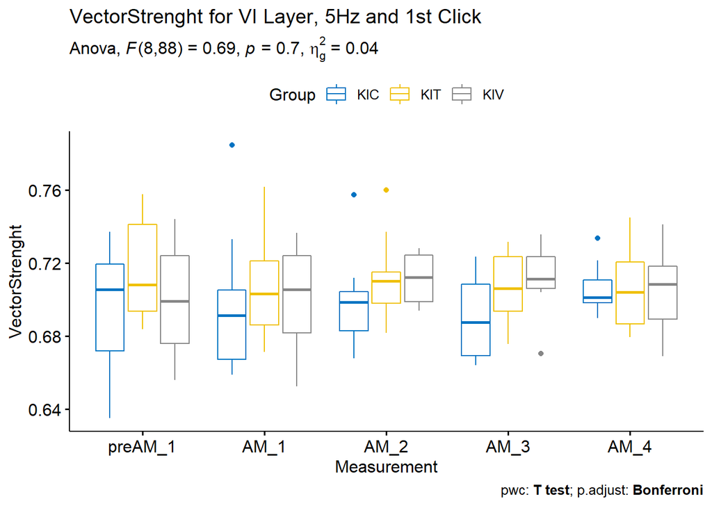

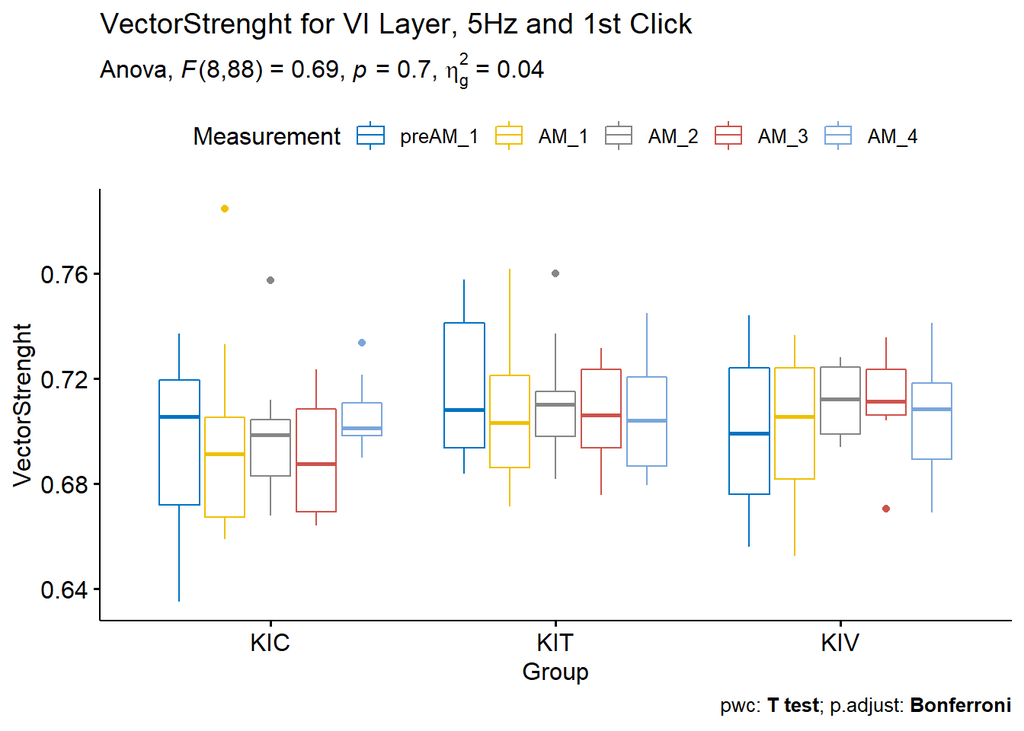